{% raw %}

{% endraw %}

{% include image.html file="/py_clone_detective/docs/images/py_clone_detector_scheme.png" %}

## Install

pip install not yet supported but will be soon!

`pip install coming_soon`

## How to use - simple use case

For a more detailed walkthrough, please see individual tutorials.

### Import and instantiate CloneCounter subclass:

The LazyCloneCounter subclass uses Dask to lazy load image series that maybe too large to fit in RAM.

{% raw %}

```python
from py_clone_detective.clone_counters import LazyCloneCounter
```

{% endraw %}

{% raw %}

```python
exp = LazyCloneCounter(
    exp_name="Marcm2a_E7F1",
    img_name_regex=r"a\dg\d\dp\d",
    pixel_size=0.275,
    tot_seg_ch="C0",
)
```

{% endraw %}

### Load images and segmentations

We add images to the LazyCloneCounter instance by passing filename "glob" for each of the image channel.

In this experiment, there are four image channels:

- C0 : DAPI (nuclear marker)
- C1 : GFP (clone marker)
- C2 : PDM1 staining (EnteroCyte marker)
- C3 : Prospero staining (EndoEndocrine marker)

{% raw %}

```python
exp.add_images(
    C0="data/MARCM_experiment/images/C0/*.tif",
    C1="data/MARCM_experiment/images/C1/*.tif",
    C2="data/MARCM_experiment/images/C2/*.tif",
    C3="data/MARCM_experiment/images/C3/*.tif",
)
```

{% endraw %}

Image data is stored in an Xarray dataset:

{% raw %}

```python
exp.image_data
```

```
<xarray.Dataset>
Dimensions:       (img_channels: 4, img_name: 67, x: 810, y: 810)
Coordinates:
  * img_channels  (img_channels) <U2 'C0' 'C1' 'C2' 'C3'
  * img_name      (img_name) <U7 'a1g01p1' 'a1g01p2' ... 'a2g13p2' 'a2g13p3'
  * y             (y) float64 0.0 0.275 0.55 0.825 ... 221.7 221.9 222.2 222.5
  * x             (x) float64 0.0 0.275 0.55 0.825 ... 221.7 221.9 222.2 222.5
Data variables:
    images        (img_channels, img_name, y, x) uint16 dask.array<chunksize=(1, 1, 810, 810), meta=np.ndarray>
```

{% endraw %}

We can access specific images using the ".sel" notation. In the example below, we index an image, load it into RAM (compute), and display it using matplotlib.

{% raw %}

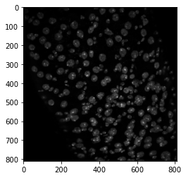

```python
import matplotlib.pyplot as plt

plt.imshow(
    exp.image_data["images"].sel(img_channels="C0", img_name="a1g01p1").compute(),
    cmap="gray",
)
```

{% endraw %}

We can segmentations in the same fashion...

**N.B.** At a minimum, py_clone_detector requires a segmentation for the "tot_seg_ch" (see above for definition). If you do not have a suitable segmentation, check out the example tutorial using StarDist.

{% raw %}

```python
exp.add_segmentations(C0="data/MARCM_experiment/segmentations/C0_stardist_segs/*.tif")
```

{% endraw %}

Segmentations have now been added to the Xarray dataset:

{% raw %}

```python
exp.image_data
```

```
<xarray.Dataset>
Dimensions:        (img_channels: 4, img_name: 67, seg_channels: 1, x: 810, y: 810)
Coordinates:
  * img_channels   (img_channels) <U2 'C0' 'C1' 'C2' 'C3'
  * img_name       (img_name) <U7 'a1g01p1' 'a1g01p2' ... 'a2g13p2' 'a2g13p3'
  * y              (y) float64 0.0 0.275 0.55 0.825 ... 221.7 221.9 222.2 222.5
  * x              (x) float64 0.0 0.275 0.55 0.825 ... 221.7 221.9 222.2 222.5
  * seg_channels   (seg_channels) <U2 'C0'
Data variables:
    images         (img_channels, img_name, y, x) uint16 dask.array<chunksize=(1, 1, 810, 810), meta=np.ndarray>
    segmentations  (seg_channels, img_name, y, x) uint16 dask.array<chunksize=(1, 1, 810, 810), meta=np.ndarray>
```

{% endraw %}